# Missing Data Lecture

Author

Chad Aldridge

```r
library(modelsummary)
library(gtsummary)
library(VIM) # visualization and imputation
library(naniar) # primarily visualization
library(mice) # primarily multiple imputation through chain equation
```

## Why care about missing data

Missing data can lead to “*biased*” estimates and standard errors. Both of these statistics are used to determine “t”, “F”, “Z” statistics from which we derive **p values and interference**.

## Missing Data Patterns

Rubin (1976) classified missing data into three **missing data mechanisms**, which describe the probabilistic relationship between the missingness indicator $R$ and the data $Y = (Y_{obs}, Y_{mis})$ ([Dong & Peng, 2013](https://pmc.ncbi.nlm.nih.gov/articles/PMC3701793/)).

Rubin’s taxonomy of missing data mechanisms

| Acronym | Full name | Missingness depends on |
| --- | --- | --- |
| MCAR | Missing Completely at Random | Neither observed nor missing data |
| MAR | Missing at Random | Observed data only |
| MNAR (NMAR) | Missing Not at Random | The missing values themselves |

## Missing Completely at Random (MCAR)

The probability that a value is missing is unrelated to both the observed and the unobserved data ([Newman, 2014](https://journals.sagepub.com/doi/10.1177/1094428114548590)):

$$P(R \mid Y_{obs}, Y_{mis}) = P(R)$$

The observed cases can be treated as a random subsample of the complete data, so complete-case analysis is unbiased, although statistical power is reduced ([UMCG, 2018](https://www.rug.nl/umcg/research/departments/epidemiology/download-area/missing-data-june-12-2018.pdf)).

**Example:** A Fugl-Meyer assessment score is lost because of a device failure or a misfiled case report form.

## Missing at Random (MAR)

Missingness depends only on observed data. After conditioning on those observed variables, it does not depend on the unobserved values ([Baraldi & Enders, 2010](https://www.uvm.edu/~statdhtx/StatPages/Missing_Data/Baraldi-Enders.html)):

$$P(R \mid Y_{obs}, Y_{mis}) = P(R \mid Y_{obs})$$

Despite the name, MAR describes *systematic* missingness. Most principled methods (multiple imputation, full information maximum likelihood, and likelihood-based mixed models) assume MAR ([van Buuren, 2018](https://stefvanbuuren.name/fimd/sec-MCAR.html)).

**Example:** Older patients or those with higher baseline NIHSS scores are more likely to miss the 90-day follow-up, and age and NIHSS are fully recorded.

## Missing Not at Random (MNAR)

Missingness depends on the unobserved values themselves, even after conditioning on the observed data ([Little, 2024](https://www.annualreviews.org/doi/pdf/10.1146/annurev-clinpsy-080822-051727)):

$$P(R \mid Y_{obs}, Y_{mis}) \neq P(R \mid Y_{obs})$$

MNAR is also called *non-ignorable* or *informative* missingness. Valid inference requires an explicit model for the missingness mechanism (e.g., selection or pattern-mixture models) and sensitivity analyses, such as delta-adjusted imputation ([UMCG, 2018](https://www.rug.nl/umcg/research/departments/epidemiology/download-area/missing-data-june-12-2018.pdf)).

**Example:** Patients with poor motor recovery skip the follow-up assessment *because* of that poor recovery.

## Key Considerations

**NoteNesting**

MCAR is a special case of MAR ([Dong & Peng, 2013](https://pmc.ncbi.nlm.nih.gov/articles/PMC3701793/)).

**WarningTestability**

Departures from MCAR can be tested (e.g., Little’s MCAR test or logistic regression of missingness on observed covariates). However, MAR cannot be distinguished from MNAR using the observed data alone ([Patient Related Outcome Measures](https://www.tandfonline.com/doi/full/10.2147/PROM.S178963)).

**TipMechanisms vs. patterns**

MCAR, MAR, and MNAR are *mechanisms* (why data are missing). Missing data *patterns* describe where gaps sit in the data matrix: univariate, monotone (e.g., longitudinal dropout), or arbitrary.

## References

- Baraldi AN, Enders CK. An introduction to modern missing data analyses. https://www.uvm.edu/~statdhtx/StatPages/Missing_Data/Baraldi-Enders.html
- Little RJA. Missing data analysis. *Annual Review of Clinical Psychology*. https://www.annualreviews.org/doi/pdf/10.1146/annurev-clinpsy-080822-051727
- Newman DA. Missing data: Five practical guidelines. *Organizational Research Methods*. 2014. https://journals.sagepub.com/doi/10.1177/1094428114548590
- Dong Y, Peng CYJ. Principled missing data methods for researchers. *SpringerPlus*. 2013;2:222. https://pmc.ncbi.nlm.nih.gov/articles/PMC3701793/
- Patient Related Outcome Measures. Analytical approaches and estimands to take account of missing patient-reported data in longitudinal studies. https://www.tandfonline.com/doi/full/10.2147/PROM.S178963
- Rubin DB. Inference and missing data. *Biometrika*. 1976;63(3):581–592.
- UMCG Epidemiology. Help! Statistics! Missing data: An introduction. 2018. https://www.rug.nl/umcg/research/departments/epidemiology/download-area/missing-data-june-12-2018.pdf
- van Buuren S. *Flexible Imputation of Missing Data*, 2nd ed. Section 1.2. https://stefvanbuuren.name/fimd/sec-MCAR.html

## Example 1 - MCAR

```r
head(Animals_na)
```

```
                     lbody   lbrain
Mountain beaver 0.30010459 2.091864
Cow             6.14203741 6.047372
Grey wolf       3.59264385 4.783316
Goat            3.31998733 4.744932
Guinea pig      0.03922071       NA
Dipliodocus     9.36734412 3.912023
```

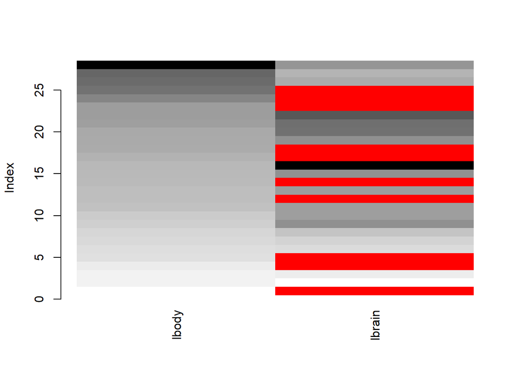

```r
# matrix plot showing the missing data pattern of lbrain and lbody
matrixplot(Animals_na, sortby = "lbody")
```

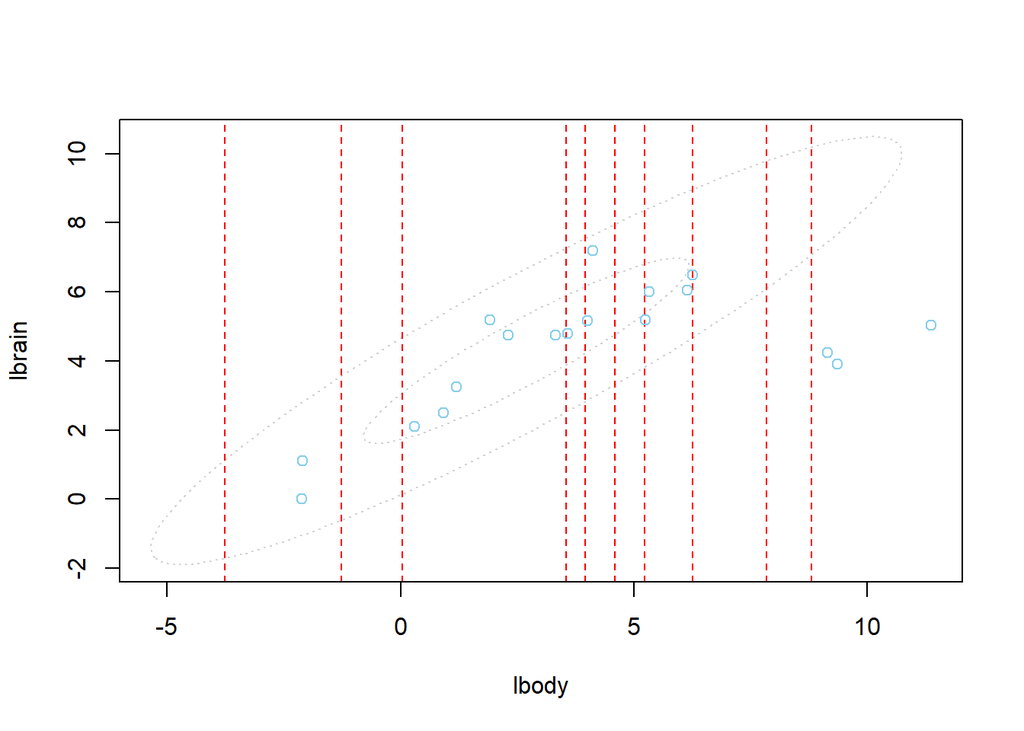

```r
# scatter plot showing where missing values of lbrain are in relation to lbody values
scattMiss(Animals_na)
```

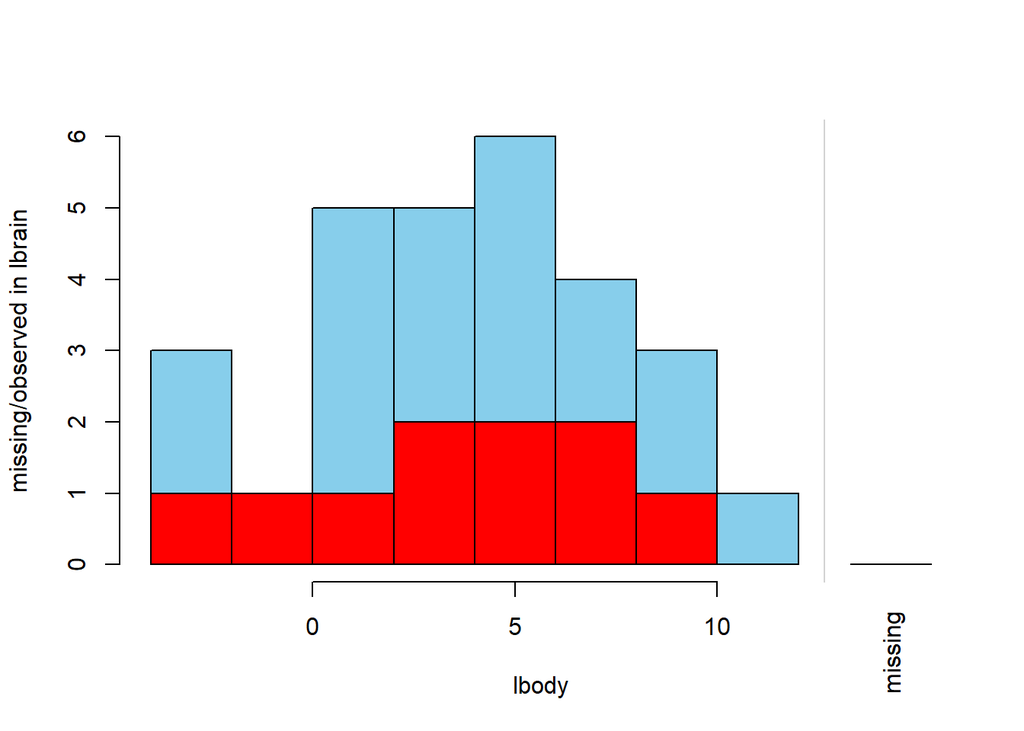

```r
# histogram with an overlay based on a missing data marker
histMiss(Animals_na)
```

```r
# let's see if lbrain values differ between observed versus missing status of lbody values
aggregate(lbody ~ is.na(lbrain), data = Animals_na, FUN = mean)
```

```
  is.na(lbrain)    lbody
1         FALSE 3.907747
2          TRUE 3.525710
```

```r
# now checking the sd across missing status of lbrain
aggregate(lbody ~ is.na(lbrain), data = Animals_na, FUN = sd)
```

```
  is.na(lbrain)    lbody
1         FALSE 3.727623
2          TRUE 4.037677
```

```r
# quick summary table of the two above
Animals_na |>
  mutate(na_status = is.na(lbrain)) |>
  tbl_summary(by = na_status, include = lbody) |>
  as_gt() |>
  gt::tab_header("Comparing lbody values between missing status of lbrain values")
```

Comparing lbody values between missing status of lbrain values

| **Characteristic** | **FALSE** N = 18<sup>1</sup> | **TRUE** N = 10<sup>1</sup> |
| --- | --- | --- |
| lbody | 3.8 (1.2, 6.1) | 4.3 (0.0, 6.3) |

<sup>1</sup> Median (Q1, Q3)

```r
# statistical test for not MCAR
naniar::mcar_test(data = Animals_na)
```

```
# A tibble: 1 × 4
  statistic    df p.value missing.patterns
      <dbl> <dbl>   <dbl>            <int>
1    0.0684     1   0.794                2
```

The non-significant p value tells us to reject the alternative hypothesis that the missing data pattern of the data set is **not** MCAR.

```r
# a simple logistic regression
summary(glm(is.na(lbrain) ~ lbody, data = Animals_na))
```

```
Call:
glm(formula = is.na(lbrain) ~ lbody, data = Animals_na)

Coefficients:
             Estimate Std. Error t value Pr(>|t|)
(Intercept)  0.381270   0.133967   2.846  0.00852 **
lbody       -0.006398   0.025348  -0.252  0.80272
---
Signif. codes:  0 '***' 0.001 '**' 0.01 '*' 0.05 '.' 0.1 ' ' 1

(Dispersion parameter for gaussian family taken to be 0.2466484)

    Null deviance: 6.4286  on 27  degrees of freedom
Residual deviance: 6.4129  on 26  degrees of freedom
AIC: 44.191

Number of Fisher Scoring iterations: 2
```

The lack of association between lbody values and missing status of lbrain values reinforce increases the likelihood that given our data, the missing data pattern is MCAR.

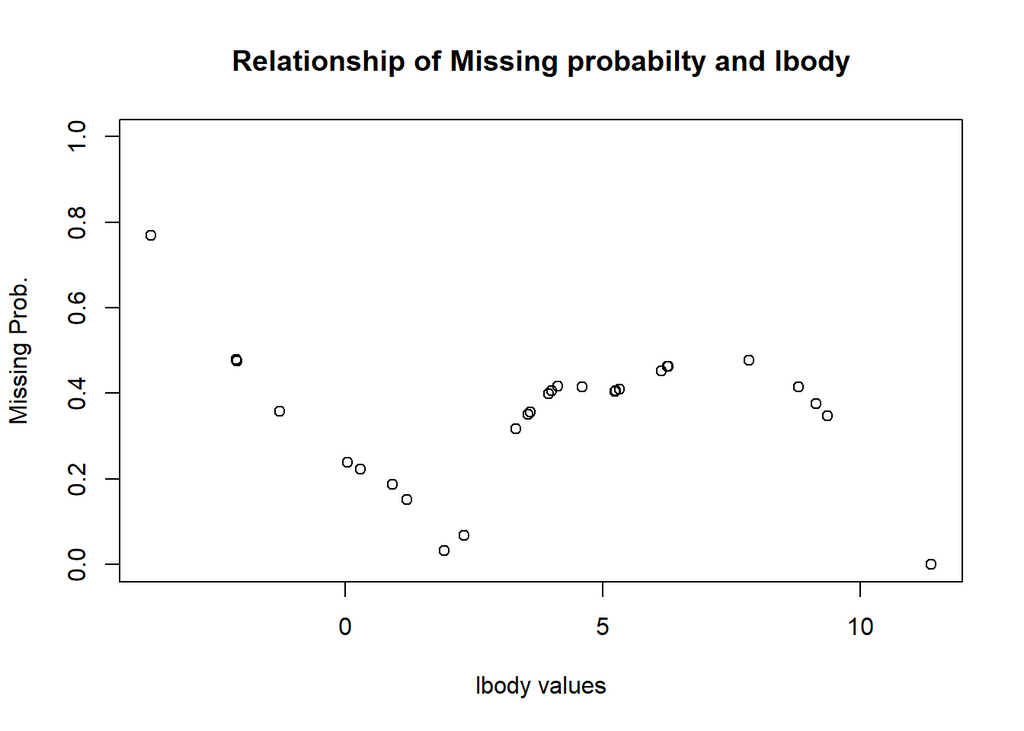

```r
# using a loess fit to determine probability of missing data
loess.fit <- loess(is.na(lbrain) ~ lbody, data = Animals_na, span = 0.7)
miss_probs <- pmin(pmax(predict(loess.fit, type = "response"),0.00001),0.9999)
plot(Animals_na$lbody, miss_probs,
     main = "Relationship of Missing probabilty and lbody", xlab = "lbody values", ylab = "Missing Prob.",
     ylim = c(0,1))
```

### Assess the centrality and variability of lbrain

```r
# observed statistics of the lbrain values
observed_mean <- mean(Animals_na$lbrain, na.rm = T)
observed_sd   <- sd(Animals_na$lbrain, na.rm = T)
observed_median <- median(Animals_na$lbrain, na.rm = T)
observed_IQR    <- IQR(Animals_na$lbrain, na.rm = T)
```

```r
# impute missing values with the variable's mean, then calculate the mean-imputed mean and sd of lbrain values
lbrain_imputed       <- impute_mean(Animals_na$lbrain)
lbrain_mean_imputed  <- mean(lbrain_imputed)
lbrain_sd_imputed    <- sd(lbrain_imputed)
```

```r
# imputing with the median
lbrain_imputed         <- impute_median(Animals_na$lbrain)
lbrain_median_imputed  <- mean(lbrain_imputed)
lbrain_sd_imputed      <- sd(lbrain_imputed)
lbrain_IQR_imputed     <- IQR(lbrain_imputed)
```

```r
# hot deck imputation
hotdecked <- hotdeck(data = Animals_na, variable = "lbrain")
hotdeck_mean <- mean(hotdecked$lbrain)
hotdeck_sd   <- sd(hotdecked$lbrain)
```

Hot decking refers to imputing missing values with observed values from other participants or samples that are similar.

```r
# table to show the difference imputation methods
data.frame("set" = c("Original", "Imputed"),
           "Means" = c(observed_mean, lbrain_mean_imputed),
           "SD" = c(observed_sd, lbrain_sd_imputed),
           "Median" = c(observed_median, lbrain_median_imputed),
           "IQR" = c(observed_IQR),
           "HD Mean" = c(NA, hotdeck_mean),
           "HD SD" = c(NA, hotdeck_sd)) |>
  gt::gt() |>
  gt::fmt_number(decimals = 3) |>
  gt::tab_header("MCAR Data Pattern")
```

MCAR Data Pattern

| set | Means | SD | Median | IQR | HD.Mean | HD.SD |
| --- | --- | --- | --- | --- | --- | --- |
| Original | 4.315 | 1.889 | 4.764 | 1.782 | NA | NA |
| Imputed | 4.315 | 1.514 | 4.476 | 1.782 | 4.620 | 1.688 |

## Example 2 - MAR

```r
# creating a simulated data set based on age and stroke severity and Fugl-Meyer measures at two time points
set.seed(2026)

# 1. Simulate complete data
n <- 500
age     <- rnorm(n, 68, 10)
nihss   <- pmax(0, round(rnorm(n, 8, 5)))
fm_base <- pmin(66, pmax(0, 50 - 1.8 * nihss + rnorm(n, 0, 6)))
fm_90   <- pmin(66, pmax(0, 10 + 0.85 * fm_base - 0.10 * age + rnorm(n, 0, 5)))
complete_df <- data.frame(age, nihss, fm_base, fm_90)
```

```r
head(complete_df)
```

```
       age nihss  fm_base    fm_90
1 73.20589    14 35.42339 24.03046
2 57.20309    10 37.40226 33.67865
3 69.39238     7 45.38248 36.59599
4 67.15251    15 20.90422 21.31353
5 61.33360     8 41.97311 41.51094
6 42.83911     7 33.68027 34.84446
```

```r
pattern = c(1,1,1,0) # the zero will make that column receive missing data
weights = c(0.5,1,-2,0) # giving relative strength of other variable to impact missing data

# cause missing data with ampute function
na_df <- ampute(data = complete_df,
                weights = weights,
                prop = 0.3,
                mech = "MAR",
                type = "RIGHT", # lower values have greater probability of missing
                patterns = pattern)
```

```r
head(na_df$amp)
```

```
       age nihss  fm_base    fm_90
1 73.20589    14 35.42339 24.03046
2 57.20309    10 37.40226 33.67865
3 69.39238     7 45.38248 36.59599
4 67.15251    15 20.90422       NA
5 61.33360     8 41.97311       NA
6 42.83911     7 33.68027 34.84446
```

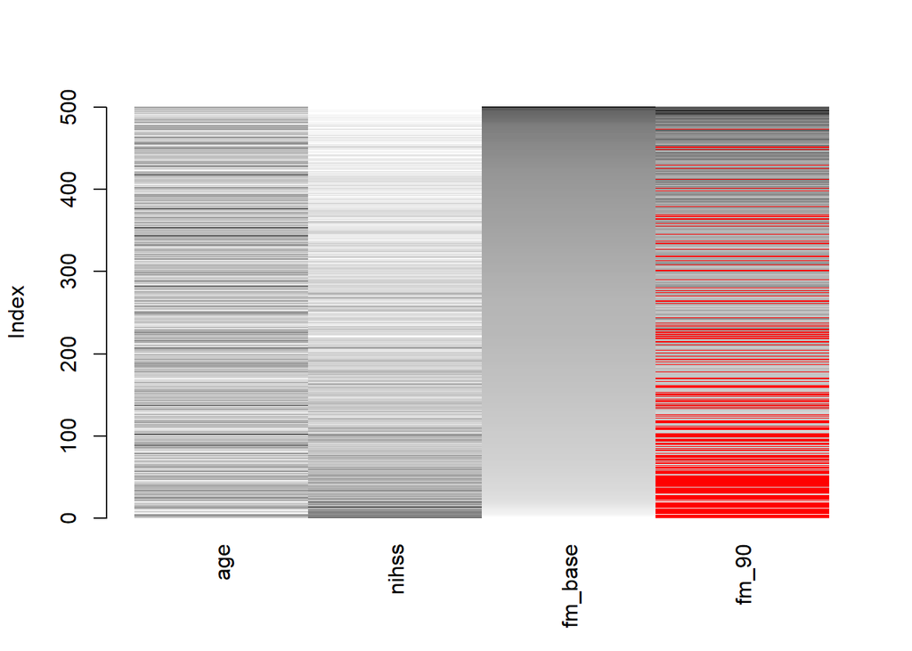

```r
# let's visualize the data like before
matrixplot(na_df$amp, sortby = "fm_base")
```

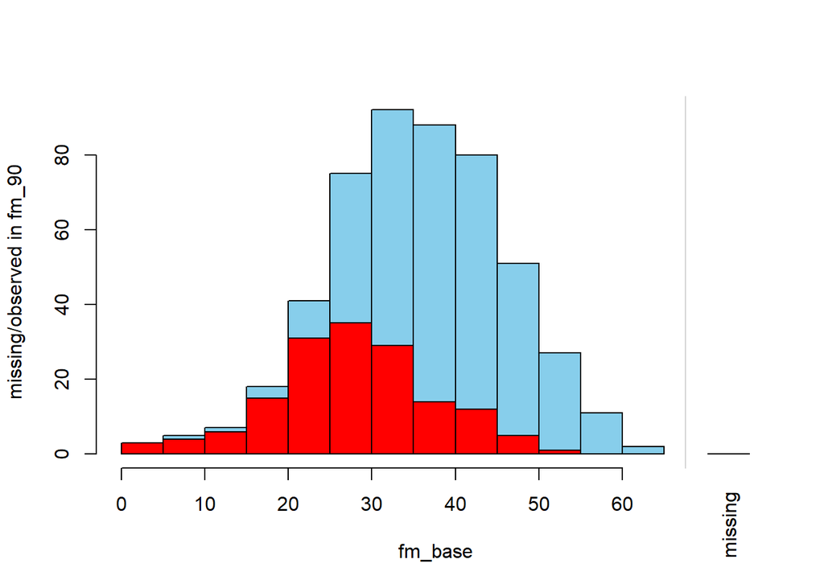

```r
histMiss(na_df$amp[,c("fm_base", "fm_90")])
```

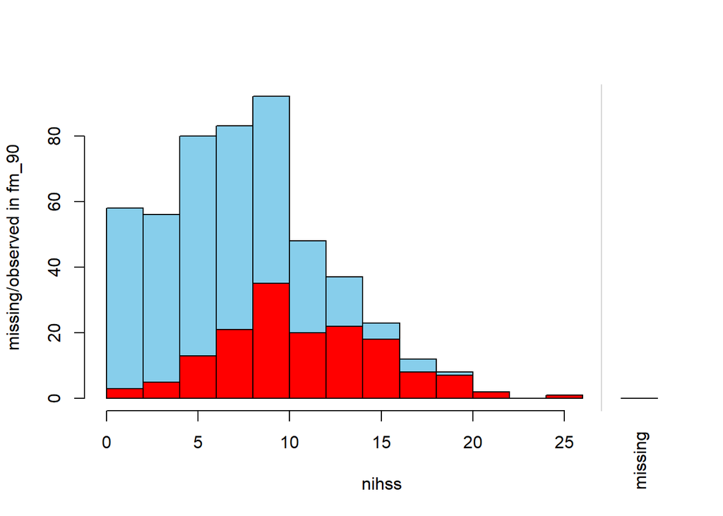

```r
histMiss(na_df$amp[,c("nihss", "fm_90")])
```

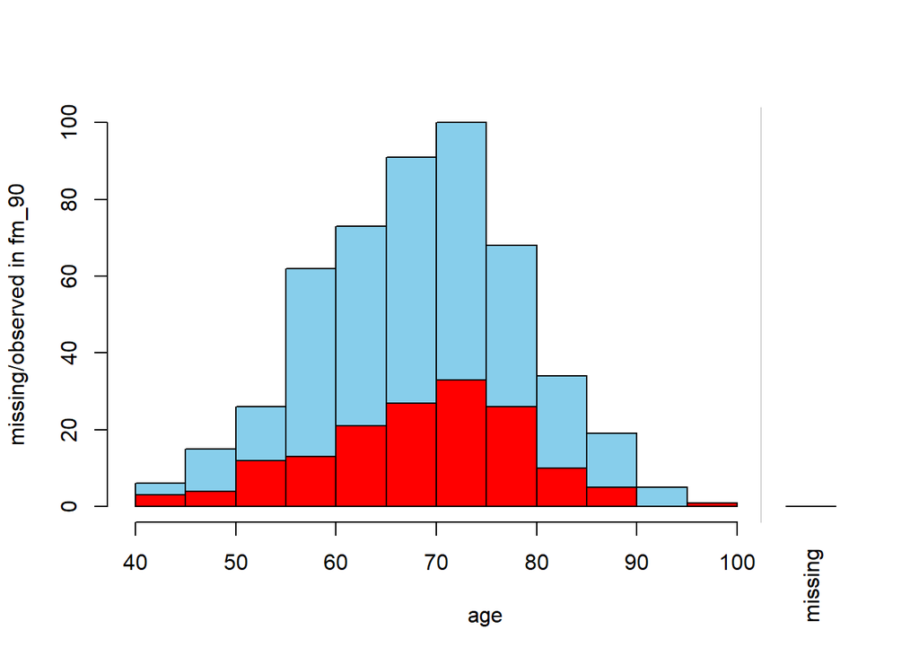

```r
histMiss(na_df$amp[,c("age", "fm_90")])
```

```r
# generate a table to see this
na_df$amp |>
  mutate(missing_stats = ifelse(is.na(fm_90), "Missing", "Observed")) |>
  tbl_summary(by = missing_stats,
              include = -fm_90) |>
  as_gt() |>
  gt::tab_header("Missing status of FM at 90 Days")
```

Missing status of FM at 90 Days

| **Characteristic** | **Missing** N = 155<sup>1</sup> | **Observed** N = 345<sup>1</sup> |
| --- | --- | --- |
| age | 69 (62, 76) | 69 (61, 75) |
| nihss | 11.0 (8.0, 14.0) | 6.0 (4.0, 9.0) |
| fm_base | 27 (22, 34) | 39 (33, 45) |

<sup>1</sup> Median (Q1, Q3)

```r
# MCAR test should be significant here
mcar_test(na_df$amp)
```

```
# A tibble: 1 × 4
  statistic    df p.value missing.patterns
      <dbl> <dbl>   <dbl>            <int>
1      124.     3       0                2
```

It is. We reject the hypothesis that the missing data pattern is a result of MCAR. However, we don’t know if the missing data pattern is MAR or MNAR.

```r
# let's compare the true mean versus the observed mean
data.frame("set" = c("True", "Observed"),
           "count" = c(nrow(complete_df), nrow(na_df$amp)),
           "mean" = c(mean(complete_df$fm_90), mean(na_df$amp$fm_90, na.rm = T)),
           "sd" = c(sd(complete_df$fm_90), sd(na_df$amp$fm_90, na.rm = T))
           ) |>
  gt::gt() |>
  gt::tab_header("90-day FM value means") |>
  gt::fmt_number(columns = 3:4,decimals = 2)
```

90-day FM value means

| set | count | mean | sd |
| --- | --- | --- | --- |
| True | 500 | 33.23 | 10.22 |
| Observed | 500 | 36.34 | 8.81 |

```r
# logistic regression to see if baseline variables predict missing 90-day fm
summary(glm(is.na(fm_90) ~ fm_base + age + nihss, data = na_df$amp, family = binomial))
```

```
Call:
glm(formula = is.na(fm_90) ~ fm_base + age + nihss, family = binomial,
    data = na_df$amp)

Coefficients:
             Estimate Std. Error z value Pr(>|z|)
(Intercept)  1.516733   1.213442   1.250    0.211
fm_base     -0.100852   0.019913  -5.065 4.09e-07 ***
age          0.003652   0.011123   0.328    0.743
nihss        0.091168   0.041234   2.211    0.027 *
---
Signif. codes:  0 '***' 0.001 '**' 0.01 '*' 0.05 '.' 0.1 ' ' 1

(Dispersion parameter for binomial family taken to be 1)

    Null deviance: 619.10  on 499  degrees of freedom
Residual deviance: 479.69  on 496  degrees of freedom
AIC: 487.69

Number of Fisher Scoring iterations: 5
```

```r
# what if we use mean impute?
fm90_mean_imputed <- na_df$amp$fm_90 |> impute_mean()

data.frame("set" = c("True", "Observed", "Mean Imputed"),
           "count" = c(nrow(complete_df), nrow(na_df$amp), length(fm90_mean_imputed)),
           "mean" = c(mean(complete_df$fm_90), mean(na_df$amp$fm_90, na.rm = T), mean(fm90_mean_imputed)),
           "sd" = c(sd(complete_df$fm_90), sd(na_df$amp$fm_90, na.rm = T), sd(fm90_mean_imputed))
           ) |>
  gt::gt() |>
  gt::tab_header("90-day FM value means") |>
  gt::fmt_number(columns = 3:4,decimals = 2)
```

90-day FM value means

| set | count | mean | sd |
| --- | --- | --- | --- |
| True | 500 | 33.23 | 10.22 |
| Observed | 500 | 36.34 | 8.81 |
| Mean Imputed | 500 | 36.34 | 7.31 |

```r
# now hot decking
hotdeckked <- hotdeck(data = na_df$amp, variable = "fm_90")


data.frame("set" = c("True", "Observed", "Mean Imputed", "Hot Decking"),
           "count" = c(nrow(complete_df), nrow(na_df$amp), length(fm90_mean_imputed), nrow(hotdeckked)),
           "mean" = c(mean(complete_df$fm_90), mean(na_df$amp$fm_90, na.rm = T), mean(fm90_mean_imputed), mean(hotdeckked$fm_90)),
           "sd" = c(sd(complete_df$fm_90), sd(na_df$amp$fm_90, na.rm = T), sd(fm90_mean_imputed), sd(hotdeckked$fm_90))
           ) |>
  gt::gt() |>
  gt::tab_header("90-day FM value means") |>
  gt::fmt_number(columns = 3:4,decimals = 2)
```

90-day FM value means

| set | count | mean | sd |
| --- | --- | --- | --- |
| True | 500 | 33.23 | 10.22 |
| Observed | 500 | 36.34 | 8.81 |
| Mean Imputed | 500 | 36.34 | 7.31 |
| Hot Decking | 500 | 36.27 | 9.11 |

As you can see, mean imputation reflects the observed mean, but lowered the variability. Hot decking also preserved the observed mean and standard deviation. Neither imputation method remove the bias due to the MAR.

### Imputation with MICE

**WarningVariables with high proportions of missing data should not be imputed**

A rule of thumb is that a variable missing no more than 20 to 30 percent of its values can be imputed. The range reflects the strength of the observed variables predicting missing status of the variable to be imputed.

```r
# multiple imputation with the mice package
imp <- mice(data = na_df$amp,
            m = 30, # number of imputed data sets to generate
            method = "pmm", # predictive means matching, similar concept to hot decking
            printFlag = F,
            seed = 65465) # set seed for reproducible values
```

**TipThe number of imputed data sets should reflect the proportion of missing data**

We want to impute the number of data sets based on the percentage of rows (e.g., samples or participants) with missing data in at least one column

```r
# we now will calculate the mean of the each imputed data set with the with() function
mice_means <- with(imp, mean(fm_90))

# now we calculate the overall mean and sd of the imputed means
# we will loop over each imp data set
mice_mean_sd <- lapply(
  complete(imp, "all"),
  function(x) data.frame("mean" = mean(x$fm_90), "sd" =  sd(x$fm_90)) # calculate mean and sd
) |>
  dplyr::bind_rows() |> # joining the 30 sets of means and sd
  colMeans() # calculating the mean of means and mean of sd's

mice_mean_sd
```

```
     mean        sd
33.457629  9.992361
```

```r
data.frame("set" = c("True", "Observed", "Mean Imputed", "Hot Decking", "MICE"),
           "count" = c(nrow(complete_df), nrow(na_df$amp), length(fm90_mean_imputed), nrow(hotdeckked), nrow(na_df$amp)),
           "mean" = c(mean(complete_df$fm_90), mean(na_df$amp$fm_90, na.rm = T), mean(fm90_mean_imputed), mean(hotdeckked$fm_90), mice_mean_sd[1]),
           "sd" = c(sd(complete_df$fm_90), sd(na_df$amp$fm_90, na.rm = T), sd(fm90_mean_imputed), sd(hotdeckked$fm_90), mice_mean_sd[2])
           ) |>
  gt::gt() |>
  gt::tab_header("90-day FM value means") |>
  gt::fmt_number(columns = 3:4,decimals = 2)
```

90-day FM value means

| set | count | mean | sd |
| --- | --- | --- | --- |
| True | 500 | 33.23 | 10.22 |
| Observed | 500 | 36.34 | 8.81 |
| Mean Imputed | 500 | 36.34 | 7.31 |
| Hot Decking | 500 | 36.27 | 9.11 |
| MICE | 500 | 33.46 | 9.99 |

The MICE method has the least amount of bias from the true mean and sd of the 90-day FM values.

**NoteModeling with MICE**

What if we want to model the relationship of age, nihss, and baseline FM on 90-day FM?

```r
# we are going to compare the model estimates across the true data set, observed data, and imputed data sets
true.fit <- lm(fm_90 ~ fm_base + age + nihss, data = complete_df)
obsv.fit <- lm(fm_90 ~ fm_base + age + nihss, data = na_df$amp)
mice.fit <- with(imp, lm(fm_90 ~ fm_base + age + nihss)) |> pool()
# pool model estimates using Rubin's rules
```

```r
modelsummary(list("true model" = true.fit, "observed model" = obsv.fit, "mice" = mice.fit))
```

|  | true model | observed model | mice |
| --- | --- | --- | --- |
| (Intercept) | 8.926 | 11.066 | 10.934 |
|  | (2.228) | (2.690) | (2.841) |
| fm_base | 0.862 | 0.842 | 0.845 |
|  | (0.034) | (0.042) | (0.043) |
| age | -0.088 | -0.108 | -0.108 |
|  | (0.020) | (0.024) | (0.024) |
| nihss | -0.028 | -0.009 | -0.007 |
|  | (0.077) | (0.094) | (0.094) |
| Num.Obs. | 500 | 345 | 500 |
| Num.Imp. |  |  | 30 |
| R2 | 0.797 | 0.735 | 0.793 |
| R2 Adj. | 0.796 | 0.732 | 0.792 |
| AIC | 2954.8 | 2031.5 |  |
| BIC | 2975.9 | 2050.7 |  |
| Log.Lik. | -1472.422 | -1010.760 |  |
| F | 649.442 | 314.694 |  |
| RMSE | 4.60 | 4.53 |  |

## Example 3 - MNAR

With **MNAR** (*missing-not-at-random*), there is an unobserved variable or influence causing the missing data pattern. For example, individuals with little recovery at 90 days post-stroke decide to leave the study.

```r
mnar_df <- ampute(data = complete_df,
                  prop = 0.3,
                  mech = "MNAR",
                  type = "LEFT",
                  patterns = pattern,
                  weights = c(0,0,0,1)) # only fm 90 days will determine missing data
```

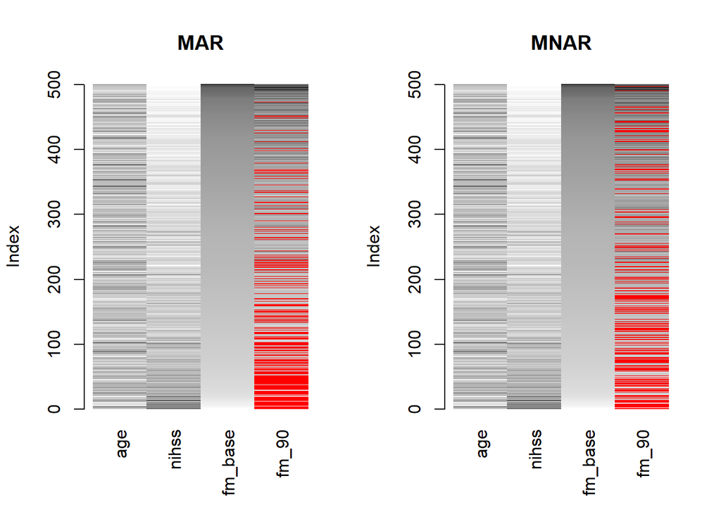

```r
# compare the MAR and MNAR missing data patterns of 90-day FM values
par(mfrow = c(1,2))
matrixplot(na_df$amp, sortby = "fm_base"); title(main = "MAR")
matrixplot(mnar_df$amp, sortby = "fm_base"); title(main = "MNAR")
```

```r
par(mfrow=c(1,1))
```

**WarningObserved data cannot distinguish between MAR and MNAR**

It is important to remember that the missing data pattern observed in your data cannot tell you whether it is the result of MAR or MNAR. You need to include other variables that may act as proxies (e.g., discharged to SNF vs IFR)

In mathematical terms $R$ is notating “missing”:

$$MAR: ~~ P(~R~|~fm_{90}~) = P(~R~|~fm_{base}~)$$

$$MNAR: ~~ P(~R~|~fm_{base},~fm_{90}~) \ne P(~R~|~fm_{base}~)$$

We can only determine if these statements are true or false by knowing the true values.

```r
true_fm90  <- mnar_df$data$fm_90
mnar.fit1  <- (glm(is.na(fm_90) ~ age + nihss + fm_base, data = mnar_df$amp))
mnar.fit2  <- (glm(is.na(fm_90) ~ age + nihss + fm_base + true_fm90, data = mnar_df$amp))
modelsummary(list("Observed Data only" = mnar.fit1, "True Data" = mnar.fit2),
             gof_map = "none",
             statistic = c("std.error", "p.value"),
             title = "Modeling MNAR Missing")
```

Modeling MNAR Missing

|  | Observed Data only | True Data |
| --- | --- | --- |
| (Intercept) | 0.858 | 1.010 |
|  | (0.210) | (0.210) |
|  | (<0.001) | (<0.001) |
| age | -0.000 | -0.002 |
|  | (0.002) | (0.002) |
|  | (0.953) | (0.404) |
| nihss | -0.002 | -0.003 |
|  | (0.007) | (0.007) |
|  | (0.762) | (0.709) |
| fm_base | -0.015 | -0.000 |
|  | (0.003) | (0.005) |
|  | (<0.001) | (0.924) |
| true_fm90 |  | -0.017 |
|  |  | (0.004) |
|  |  | (<0.001) |

By using the true fm90 values, we show that the FM baseline values do not predict missing status of 90-day FM values.

```r
# mean imputation
mean_impute <- impute_mean(mnar_df$amp$fm_90)

data.frame("set" = c("True", "Observed", "Mean Imputed"),
           "mean" = c(mean(complete_df$fm_90), mean(mnar_df$amp$fm_90, na.rm = T), mean(mean_impute)),
           "sd" = c(sd(complete_df$fm_90), sd(mnar_df$amp$fm_90, na.rm = T), sd(mean_impute))
           ) |>
  gt::gt() |>
  gt::fmt_number(decimals = 2) |>
  gt::tab_header("MNAR True versus Observed")
```

MNAR True versus Observed

| set | mean | sd |
| --- | --- | --- |
| True | 33.23 | 10.22 |
| Observed | 35.67 | 9.36 |
| Mean Imputed | 35.67 | 7.83 |

As you can see here, the bias from the true mean remains with mean imputation. It also artificially reduces the standard deviation. This behavior may result in a false positive difference over time or between experimental groups.

```r
# trying to see what happens with mice

imp2 <- mice(data = mnar_df$amp,
             m = 30,
             method = "pmm",
             printFlag = F)
```

```r
mnar_mean_sd <- lapply(
  complete(imp2, "all"),
  function(i) {data.frame("mean" = mean(i$fm_90), "sd" = sd(i$fm_90))}
) |>
  dplyr::bind_rows() |>
  colMeans()

data.frame("set" = c("True", "Observed", "MICE"),
           "mean" = c(mean(complete_df$fm_90), mean(mnar_df$amp$fm_90, na.rm = T), mnar_mean_sd[1]),
           "sd" = c(sd(complete_df$fm_90), sd(mnar_df$amp$fm_90, na.rm = T), mnar_mean_sd[2])
           ) |>
  gt::gt() |>
  gt::fmt_number(decimals = 2) |>
  gt::tab_header("MNAR True versus Observed")
```

MNAR True versus Observed

| set | mean | sd |
| --- | --- | --- |
| True | 33.23 | 10.22 |
| Observed | 35.67 | 9.36 |
| MICE | 33.89 | 9.87 |

**Tiphighly correlated variable can act as proxies to the MNAR variable**

In this case, baseline FM values strongly predict 90-day FM values even though the missing data pattern is due to low 90-day FM values representing limited recovery.

```r
# comparing mice on MNAR with true
f <- formula(fm_90 ~ fm_base + age + nihss) # formula

true.fit <- lm(f, data = complete_df) # true model
mice.fit <- pool(with(imp2, lm(f))) # mice model for MNAR
```

```r
# model comparison table
modelsummary(list("True" = true.fit, "MICE" = mice.fit),
             gof_omit = "(AIC|BIC|Log|F|RMSE)", title = "MICE performance with MNAR")
```

MICE performance with MNAR

[output not shown]